# Data_cleaning

Cecilia Albert-Black

2025-11-13

Here I will walk through cleaning and feature engineering the Bioavailability Master Spreadsheet. We will run this for each tab separately to create a Bioavailability Master Spreadsheet Clean version with 3 tabs.

Workflow overview

- Standardize units of all concentration variables to uM
- Create new numeric variables:
  - Total bioavailable element
  - Relative proportion of bioavailable element
- Create new categorical variables
  - From numeric inherent stream characteristics (development, distance from main stem, drainage area, and relative elevation)

## I. Import Dataset

Set the working directory to the repo

```r
setwd("C:/Users/q4q/OneDrive - Oak Ridge National Laboratory/Research/Bioavailability Project/1. Spatial Assessment/Data/Spatial Assessment of Bioavailability Project/3. Dataset cleaning")
```

Upload Bioavailability_Master_Spreadsheet.xlsx

```r
#load package (must be installed first)
library(readxl)

dat <- read_excel("C:/Users/q4q/OneDrive - Oak Ridge National Laboratory/Research/Bioavailability Project/1. Spatial Assessment/Data/Spatial Assessment of Bioavailability Project/2. Dataset merging/Bioavailability_Master_Spreadsheet.xlsx",
                  sheet = "HA 10% Closed System")
```

```r
head(dat)
```

```
## # A tibble: 6 × 57
##   Sample_ID Site    Date                Regime    Flow_state    pH Temp_C DOC_uM
##   <chr>     <chr>   <dttm>              <chr>     <chr>      <dbl>  <dbl>  <dbl>
## 1 WaDE_62   MTN1.1  2023-06-23 00:00:00 NonPeren… Flowing     7.21   16.5   75.8
## 2 WaDE_63   EFK13.8 2023-06-23 00:00:00 Perennial Flowing     8.28   18.6  160
## 3 WaDE_64   MTN4    2023-06-23 00:00:00 Perennial Flowing     8.29   15.8   35.8
## 4 WaDE_65   MTN2    2023-06-23 00:00:00 NonPeren… Pooled      8.32   18.7  528.
## 5 WaDE_66   MCA3.3  2023-06-23 00:00:00 NonPeren… Flowing     7.67   16.2  119.
## 6 WaDE_67   MCA3.2  2023-06-23 00:00:00 NonPeren… Flowing     7.49   16.5   81.7
## # ℹ 49 more variables: Ca_uM <dbl>, Mg_uM <dbl>, Na_uM <dbl>, K_uM <dbl>,
## #   SO4_uM <dbl>, Cl_uM <dbl>, DIC_uM <dbl>, Zn_uM <dbl>, Cu_uM <dbl>,
## #   Network <chr>, Relative_elevation_m <dbl>, Dist_from_EFPC_km <dbl>,
## #   Drainage_area_km2 <dbl>, Developed_lulc <dbl>, Free_Zn_M <dbl>,
## #   ZnOH_M <dbl>, Zn_OH_2_M <dbl>, ZnCO3_M <dbl>, ZnHCO3_M <dbl>,
## #   ZnSO4_M <dbl>, ZnCl_M <dbl>, ZnS_M <dbl>, TOrg_Zn_M <dbl>,
## #   BL_Zn_mol_kg_Zn <dbl>, BL_Ca_mol_kg_Zn <dbl>, BL_H_mol_kg_Zn <dbl>, …
```

Inspect the structure

```r
str(dat)
```

```
## tibble [386 × 57] (S3: tbl_df/tbl/data.frame)
##  $ Sample_ID                    : chr [1:386] "WaDE_62" "WaDE_63" "WaDE_64" "WaDE_65" ...
##  $ Site                         : chr [1:386] "MTN1.1" "EFK13.8" "MTN4" "MTN2" ...
##  $ Date                         : POSIXct[1:386], format: "2023-06-23" "2023-06-23" ...
##  $ Regime                       : chr [1:386] "NonPerennial" "Perennial" "Perennial" "NonPerennial" ...
##  $ Flow_state                   : chr [1:386] "Flowing" "Flowing" "Flowing" "Pooled" ...
##  $ pH                           : num [1:386] 7.21 8.28 8.29 8.32 7.67 7.49 7.62 7.55 8.13 8.17 ...
##  $ Temp_C                       : num [1:386] 16.5 18.6 15.8 18.7 16.2 16.5 17.3 16.8 17.3 19 ...
##  $ DOC_uM                       : num [1:386] 75.8 160 35.8 527.5 119.2 ...
##  $ Ca_uM                        : num [1:386] 1498 1338 271 306 164 ...
##  $ Mg_uM                        : num [1:386] 458 333 182 75.6 79.9 24.7 172 237 210 439 ...
##  $ Na_uM                        : num [1:386] 212 295 90 7 88 66 95 134 115 398 ...
##  $ K_uM                         : num [1:386] 37 54 24.8 46.4 21.2 12.2 22.5 28.1 24.5 60.2 ...
##  $ SO4_uM                       : num [1:386] 38.2 139 29.7 7.5 54.3 37.1 21.8 38.8 31.2 203 ...
##  $ Cl_uM                        : num [1:386] 174 172 80 16 87 77 80 93 90 246 ...
```

[output cut: 43 more lines]

Move stream inherent characteristics to the first few columns

```r
library(dplyr)
dat <- dat %>%
  relocate(Network, Relative_elevation_m, Dist_from_EFPC_km, Drainage_area_km2, Developed_lulc, .before = pH)

# Check
head(dat)
```

```
## # A tibble: 6 × 57
##   Sample_ID Site    Date                Regime       Flow_state Network
##   <chr>     <chr>   <dttm>              <chr>        <chr>      <chr>
## 1 WaDE_62   MTN1.1  2023-06-23 00:00:00 NonPerennial Flowing    MTN
## 2 WaDE_63   EFK13.8 2023-06-23 00:00:00 Perennial    Flowing    EFK
## 3 WaDE_64   MTN4    2023-06-23 00:00:00 Perennial    Flowing    MTN
## 4 WaDE_65   MTN2    2023-06-23 00:00:00 NonPerennial Pooled     MTN
## 5 WaDE_66   MCA3.3  2023-06-23 00:00:00 NonPerennial Flowing    MCA
## 6 WaDE_67   MCA3.2  2023-06-23 00:00:00 NonPerennial Flowing    MCA
## # ℹ 51 more variables: Relative_elevation_m <dbl>, Dist_from_EFPC_km <dbl>,
## #   Drainage_area_km2 <dbl>, Developed_lulc <dbl>, pH <dbl>, Temp_C <dbl>,
## #   DOC_uM <dbl>, Ca_uM <dbl>, Mg_uM <dbl>, Na_uM <dbl>, K_uM <dbl>,
## #   SO4_uM <dbl>, Cl_uM <dbl>, DIC_uM <dbl>, Zn_uM <dbl>, Cu_uM <dbl>,
## #   Free_Zn_M <dbl>, ZnOH_M <dbl>, Zn_OH_2_M <dbl>, ZnCO3_M <dbl>,
## #   ZnHCO3_M <dbl>, ZnSO4_M <dbl>, ZnCl_M <dbl>, ZnS_M <dbl>, TOrg_Zn_M <dbl>,
## #   BL_Zn_mol_kg_Zn <dbl>, BL_Ca_mol_kg_Zn <dbl>, BL_H_mol_kg_Zn <dbl>, …
```

## II. Unit Conversions

Convert molar concentrations to uM and nM

```r
library(dplyr)
library(stringr)

dat <- dat %>%
  mutate(
    # ---------------------------------------------------------
    # 1) If you have *_uM but not *_M, create *_M
    # ---------------------------------------------------------
    across(
      matches("_uM$", ignore.case = FALSE),
      ~ .x * 1e-6,
      .names = "{str_remove(.col, '_uM$')}_M"
    ),

    # ---------------------------------------------------------
    # 2) From *_M create *_uM and *_nM (case-sensitive, so _m won't match)
    # ---------------------------------------------------------
    across(
      matches("_M$", ignore.case = FALSE),
      list(uM = ~ .x * 1e6, nM = ~ .x * 1e9),
      .names = "{str_remove(.col, '_M$')}_{.fn}"
    ),

    # ---------------------------------------------------------
    # 3) Keep BL-bound conversions as-is
    # ---------------------------------------------------------
    across(
      ends_with("_mol_kg_Zn"),
      list(umol_g_Zn = ~ .x * 1e3, nmol_g_Zn = ~ .x * 1e6),
      .names = "{str_remove(.col, '_mol_kg_Zn$')}_{.fn}"
    ),
    across(
      ends_with("_mol_kg_Cu"),
      list(umol_g_Cu = ~ .x * 1e3, nmol_g_Cu = ~ .x * 1e6),
      .names = "{str_remove(.col, '_mol_kg_Cu$')}_{.fn}"
    )
  )
```

Checks

```r
# No duplicate column names
anyDuplicated(names(dat))
```

```
## [1] 0
```

```r
# Elevation should NOT have uM/nM/M versions
names(dat)[grepl("Relative_elevation_m_", names(dat))]
```

```
## character(0)
```

## III. Create New Numeric Variables

### i. Total Bioavailable Element

Total biotic ligand (TBL)-bound trace elements = TBL-element+ TBL-element hydroxide

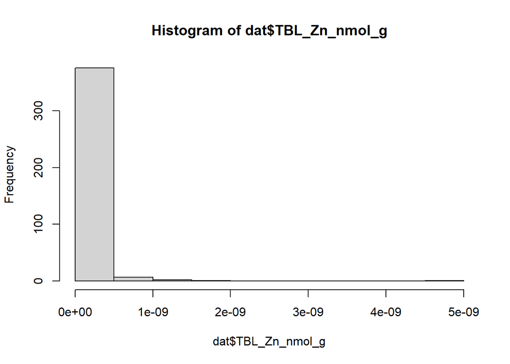

```r
# TBL-Zn
dat$TBL_Zn_nmol_g <- dat$BL_Zn_nmol_g_Zn + dat$BL_ZnOH_nmol_g_Zn

# TBL-Cu
dat$TBL_Cu_nmol_g <- dat$BL_Cu_nmol_g_Cu + dat$BL_CuOH_nmol_g_Cu

# Check
hist(dat$TBL_Zn_nmol_g)
```

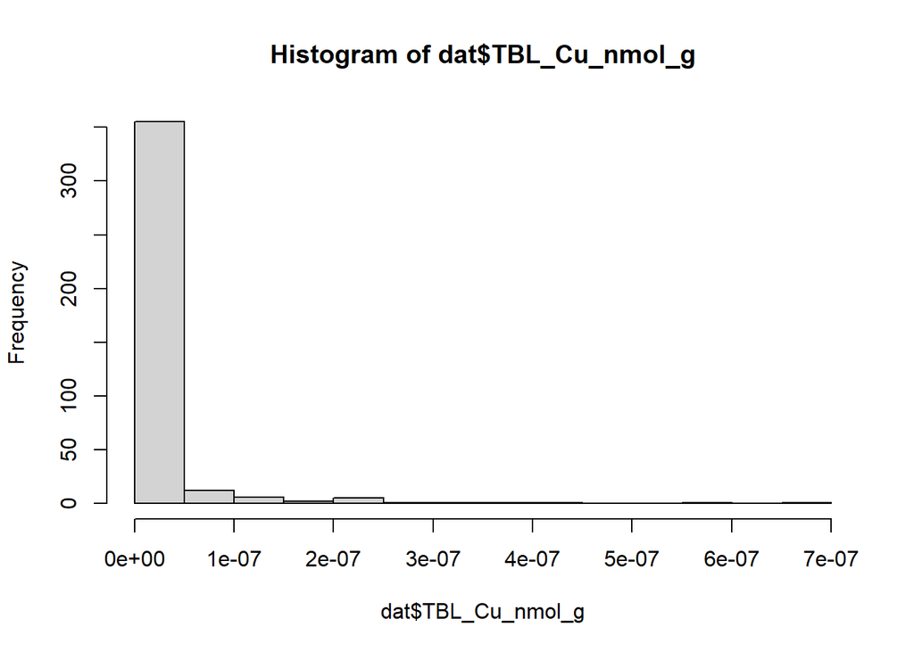

```r
hist(dat$TBL_Cu_nmol_g)
```

### i. Relative Proportion of Bioavailable Element

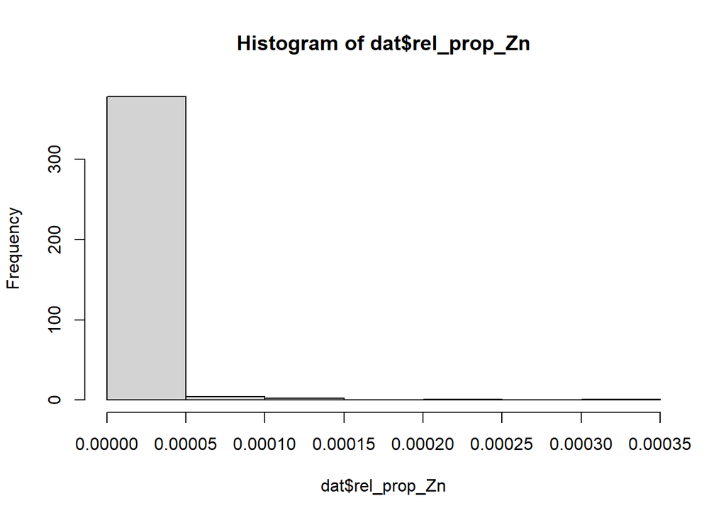

```r
# Zinc
dat$rel_prop_Zn <- dat$Free_Zn_uM / dat$Zn_uM

# Copper
dat$rel_prop_Cu <- dat$Free_Cu_uM / dat$Cu_uM

# Check
hist(dat$rel_prop_Zn)
```

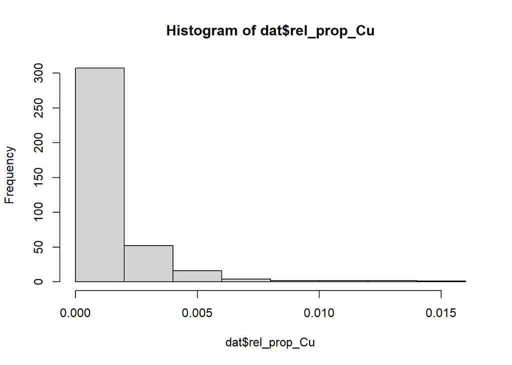

```r
hist(dat$rel_prop_Cu)
```

## IV. Create New Categorical Variables

### i. Stream Type

Distinguish tributaries from the EFPC main stem (within the EFK network)

```r
dat <- dat %>%
  mutate(
    Type = if_else(
      Network == "EFK",
      "Main Stem",
      "Tributaries"
    ) %>% factor(levels = c("Main Stem", "Tributaries"))
  )

# Check
table(dat$Type)
```

```
##
##   Main Stem Tributaries
##         106         280
```

Check for NAs

```r
sum(is.na(dat$Type))
```

```
## [1] 0
```

### ii. Orientation

As a proxy for bedrock lithology:

- North slope
  - Networks: BSL, WBK, MCA, MTN, NBO
- South slope
  - Networks: S_TRIB
- Main stem
  - Networks: EFK

```r
dat <- dat %>%
  mutate(
    Orientation = case_when(
      Network %in% c("WBK", "MCA", "MTN", "NBO", "BSL") ~ "North slope",
      Network %in% c("S_TRIB") ~ "South slope",
      Network %in% c("EFK") ~ "Main stem",
      TRUE ~ NA_character_
    ) %>%
      factor(levels = c("North slope", "South slope", "Main stem"))
  )

# Check
table(dat$Orientation)
```

```
##
## North slope South slope   Main stem
##         237          43         106
```

Check for NAs

```r
sum(is.na(dat$Orientation))
```

```
## [1] 0
```

### i. Development

Categorizing developed land use and land cover (LULC) will be based on a modified version of the MRLC National Land Cover Database Class Legend and Description. Our categories will be as follows

- <49% developed LULC = low intensity
- 50-79% developed LULC = medium intensity
- >80% developed LULC = high intensity

```r
dat <- dat %>%
  mutate(
    Development = case_when(
      Developed_lulc < 50 ~ "Low",
      Developed_lulc >= 50 & Developed_lulc < 80 ~ "Medium",
      Developed_lulc >= 80 ~ "High"
    ) %>%
      factor(levels = c("Low", "Medium", "High"))
  )

# Check
table(dat$Development)
```

```
##
##    Low Medium   High
##    110    145    131
```

Check for NAs

```r
sum(is.na(dat$Development))
```

```
## [1] 0
```

### ii. Distance from Main Stem

Omitting the main stem, let’s assess the distribution of distance from main stem values

```r
tribs <- dat %>%
  filter(Type != "Main Stem")

tribs
```

```
## # A tibble: 280 × 154
##    Sample_ID Site   Date                Regime       Flow_state Network
##    <chr>     <chr>  <dttm>              <chr>        <chr>      <chr>
##  1 WaDE_62   MTN1.1 2023-06-23 00:00:00 NonPerennial Flowing    MTN
##  2 WaDE_64   MTN4   2023-06-23 00:00:00 Perennial    Flowing    MTN
##  3 WaDE_65   MTN2   2023-06-23 00:00:00 NonPerennial Pooled     MTN
##  4 WaDE_66   MCA3.3 2023-06-23 00:00:00 NonPerennial Flowing    MCA
##  5 WaDE_67   MCA3.2 2023-06-23 00:00:00 NonPerennial Flowing    MCA
##  6 WaDE_68   MCA4   2023-06-23 00:00:00 Perennial    Flowing    MCA
##  7 WaDE_69   MCA1   2023-06-23 00:00:00 Perennial    Flowing    MCA
##  8 WaDE_70   MCA2   2023-06-23 00:00:00 NonPerennial Flowing    MCA
##  9 WaDE_72   MCA3.1 2023-06-23 00:00:00 NonPerennial Flowing    MCA
## 10 WaDE_73   WBK1   2023-06-23 00:00:00 Perennial    Flowing    WBK
## # ℹ 270 more rows
## # ℹ 148 more variables: Relative_elevation_m <dbl>, Dist_from_EFPC_km <dbl>,
## #   Drainage_area_km2 <dbl>, Developed_lulc <dbl>, pH <dbl>, Temp_C <dbl>,
## #   DOC_uM <dbl>, Ca_uM <dbl>, Mg_uM <dbl>, Na_uM <dbl>, K_uM <dbl>,
## #   SO4_uM <dbl>, Cl_uM <dbl>, DIC_uM <dbl>, Zn_uM <dbl>, Cu_uM <dbl>,
## #   Free_Zn_M <dbl>, ZnOH_M <dbl>, Zn_OH_2_M <dbl>, ZnCO3_M <dbl>,
## #   ZnHCO3_M <dbl>, ZnSO4_M <dbl>, ZnCl_M <dbl>, ZnS_M <dbl>, …
```

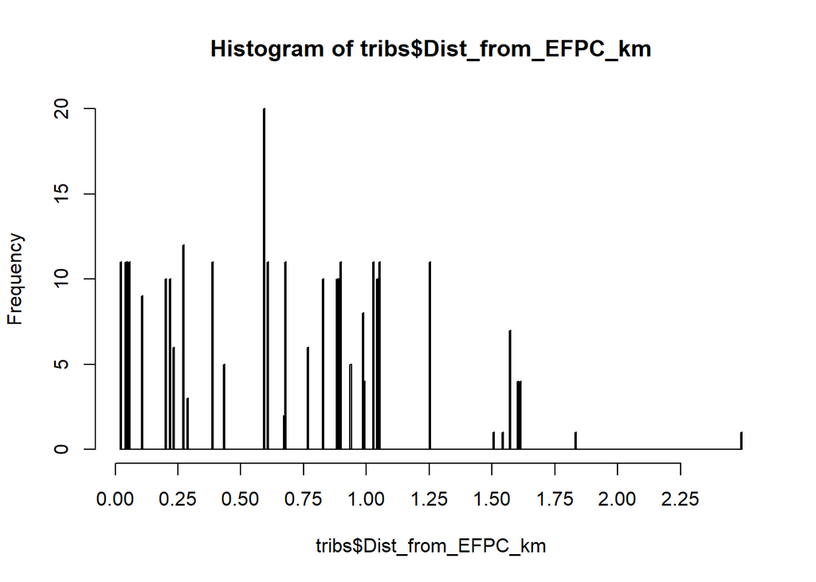

```r
hist(tribs$Dist_from_EFPC_km, breaks = 386, xaxt = "n")

axis(
  side = 1,
  at = seq(
    from = 0,
    to = max(dat$Dist_from_EFPC_km, na.rm = TRUE),
    by = 0.25
  )
)
```

Check the quartiles

```r
summary(tribs$Dist_from_EFPC_km)
```

```
##    Min. 1st Qu.  Median    Mean 3rd Qu.    Max.
##  0.0230  0.2190  0.6100  0.6498  0.9880  2.4920
```

Dividing the variable by quartiles (1st and 3rd):

- <0.22 km
- 0.22-0.99
- >0.99 km

```r
dat <- dat %>%
  mutate(
    Distance_from_EFPC = case_when(
      Type == "Main Stem" ~ "Main stem",
      Dist_from_EFPC_km < 0.22 ~ "<0.22 km",
      Dist_from_EFPC_km >= 0.22 & Dist_from_EFPC_km <= 0.99 ~ "0.22-0.99 km",
      Dist_from_EFPC_km > 0.99 ~ ">0.99 km",
      TRUE ~ NA_character_
    ) %>%
      factor(levels = c("Main stem", "<0.22 km", "0.22-0.99 km", ">0.99 km"))
  )

# Check
table(dat$Distance_from_EFPC)
```

```
##
##    Main stem     <0.22 km 0.22-0.99 km     >0.99 km
##          106           73          141           66
```

Check for NAs

```r
sum(is.na(dat$Distance_from_EFPC))
```

```
## [1] 0
```

### iii. Drainage Area

To classify drainage area (km2) into categories, we’ll first inspect its distribution

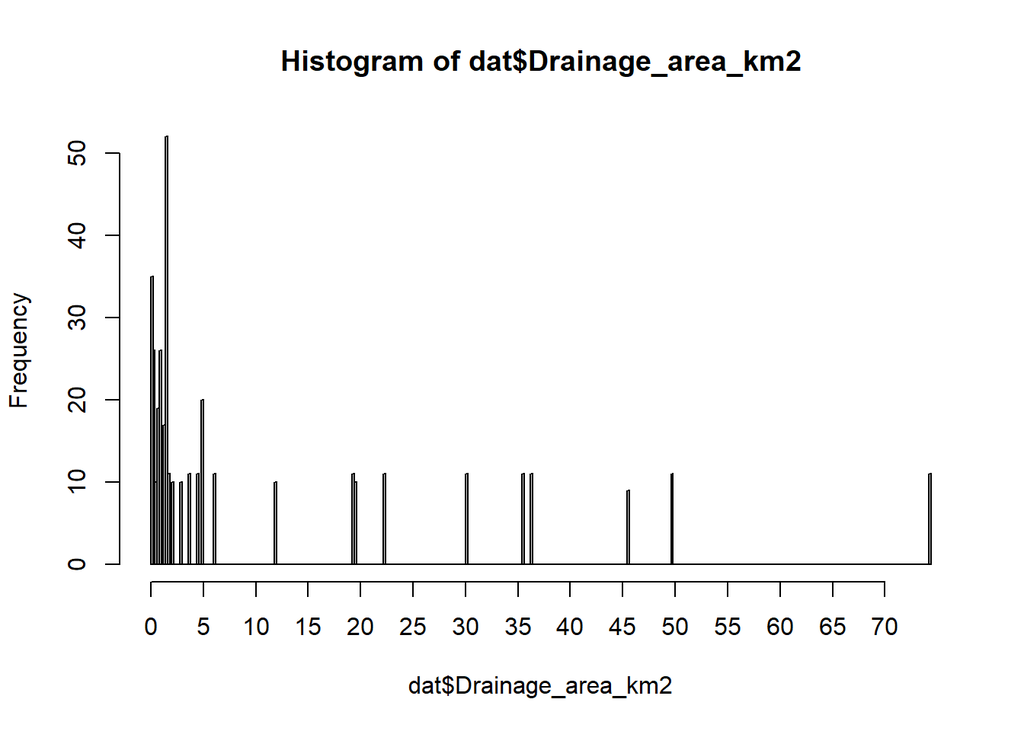

```r
hist(dat$Drainage_area_km2, breaks = 386, xaxt = "n")   # remove default axis

axis(
  side = 1,
  at = seq(
    from = 0,
    to = max(dat$Drainage_area_km2, na.rm = TRUE),
    by = 5                                           # tick every 5 km2
  )
)
```

Let’s check to quartiles

```r
summary(dat$Drainage_area_km2)
```

```
##    Min. 1st Qu.  Median    Mean 3rd Qu.    Max.
##    0.01    0.94    1.51   10.76   11.81   74.22
```

- <0.94 km2
- 0.94-11.81 km2
- >11.81 km2

```r
library(dplyr)

dat <- dat %>%
  mutate(
    Drainage_area = case_when(
      Drainage_area_km2 < 0.94 ~ "<0.94 km2",
      Drainage_area_km2 >= 0.94 & Drainage_area_km2 <= 11.81 ~ "0.94-11.81 km2",
      Drainage_area_km2 > 11.81 ~ ">11.81 km2",
      TRUE ~ NA_character_
    ) %>%
      factor(levels = c("<0.94 km2", "0.94-11.81 km2", ">11.81 km2"))
  )

# Check
table(dat$Drainage_area)
```

```
##
##      <0.94 km2 0.94-11.81 km2     >11.81 km2
##             94            196             96
```

Check for NAs

```r
sum(is.na(dat$Drainage_area))
```

```
## [1] 0
```

### iv. Relative Elevation

To classify relative elevation (m) into categories, we first have to omit 0 values which correspond to the Main Stem

```r
tribs <- dat %>%
  filter(Relative_elevation_m != "0")
```

Now we’ll first inspect the distribution of relative elevation distribution

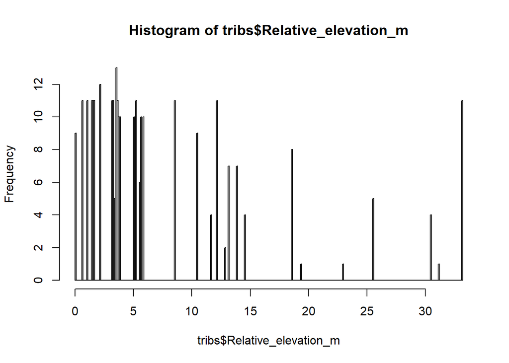

```r
hist(tribs$Relative_elevation_m, breaks = 386, xaxt = "n")   # remove default axis

axis(
  side = 1,
  at = seq(
    from = 0,
    to = max(tribs$Relative_elevation_m, na.rm = TRUE),
    by = 5                                           # tick every 5 km2
  )
)
```

Check its quartiles

```r
summary(tribs$Relative_elevation_m)
```

```
##    Min. 1st Qu.  Median    Mean 3rd Qu.    Max.
##   0.017   2.134   3.832   7.422  10.495  33.182
```

Breaks at 1st and 3rd quartiles

```r
library(dplyr)

dat <- dat %>%
  mutate(
    Relative_elevation = case_when(
      Relative_elevation_m == 0 ~ "0 m",
      Relative_elevation_m < 2.1 ~ "<2.1 m",
      Relative_elevation_m >= 2.1 & Relative_elevation_m <= 10.5 ~ "2.1-10.5 m",
      Relative_elevation_m > 10.5 ~ ">10.5 m",
      TRUE ~ NA_character_
    ) %>% factor(levels = c("<2.1 m","2.1-10.5 m",">10.5 m", "0 m"))
  )

# Check
summary(dat$Relative_elevation)
```

```
##     <2.1 m 2.1-10.5 m    >10.5 m        0 m
##         64        150         66        106
```

Check for NAs

```r
sum(is.na(dat$Relative_elevation))
```

```
## [1] 0
```

## V. Save to Excel

Double check before saving

```r
View(dat)
```

Bring new variables describing stream inherent characteristics to the front

```r
library(dplyr)

dat <- dat %>%
  relocate(Type,
           Development,
           Distance_from_EFPC,
           Drainage_area,
           Orientation,
           Relative_elevation,
           .before = pH)

# Check
head(dat)
```

```
## # A tibble: 6 × 157
##   Sample_ID Site    Date                Regime       Flow_state Network
##   <chr>     <chr>   <dttm>              <chr>        <chr>      <chr>
## 1 WaDE_62   MTN1.1  2023-06-23 00:00:00 NonPerennial Flowing    MTN
## 2 WaDE_63   EFK13.8 2023-06-23 00:00:00 Perennial    Flowing    EFK
## 3 WaDE_64   MTN4    2023-06-23 00:00:00 Perennial    Flowing    MTN
## 4 WaDE_65   MTN2    2023-06-23 00:00:00 NonPerennial Pooled     MTN
## 5 WaDE_66   MCA3.3  2023-06-23 00:00:00 NonPerennial Flowing    MCA
## 6 WaDE_67   MCA3.2  2023-06-23 00:00:00 NonPerennial Flowing    MCA
## # ℹ 151 more variables: Relative_elevation_m <dbl>, Dist_from_EFPC_km <dbl>,
## #   Drainage_area_km2 <dbl>, Developed_lulc <dbl>, Type <fct>,
## #   Development <fct>, Distance_from_EFPC <fct>, Drainage_area <fct>,
## #   Orientation <fct>, Relative_elevation <fct>, pH <dbl>, Temp_C <dbl>,
## #   DOC_uM <dbl>, Ca_uM <dbl>, Mg_uM <dbl>, Na_uM <dbl>, K_uM <dbl>,
## #   SO4_uM <dbl>, Cl_uM <dbl>, DIC_uM <dbl>, Zn_uM <dbl>, Cu_uM <dbl>,
## #   Free_Zn_M <dbl>, ZnOH_M <dbl>, Zn_OH_2_M <dbl>, ZnCO3_M <dbl>, …
```

Check the structure one last time before saving

```r
str(dat)
```

```
## tibble [386 × 157] (S3: tbl_df/tbl/data.frame)
##  $ Sample_ID                     : chr [1:386] "WaDE_62" "WaDE_63" "WaDE_64" "WaDE_65" ...
##  $ Site                          : chr [1:386] "MTN1.1" "EFK13.8" "MTN4" "MTN2" ...
##  $ Date                          : POSIXct[1:386], format: "2023-06-23" "2023-06-23" ...
##  $ Regime                        : chr [1:386] "NonPerennial" "Perennial" "Perennial" "NonPerennial" ...
##  $ Flow_state                    : chr [1:386] "Flowing" "Flowing" "Flowing" "Pooled" ...
##  $ Network                       : chr [1:386] "MTN" "EFK" "MTN" "MTN" ...
##  $ Relative_elevation_m          : num [1:386] 3.83 0 33.18 12.87 30.45 ...
##  $ Dist_from_EFPC_km             : num [1:386] 0.205 0 1.255 0.673 0.995 ...
##  $ Drainage_area_km2             : num [1:386] 1.42 30.18 0.3 0.74 0.16 ...
##  $ Developed_lulc                : num [1:386] 63.6 64.7 41.2 54.4 58.5 ...
##  $ Type                          : Factor w/ 2 levels "Main Stem","Tributaries": 2 1 2 2 2 2 2 2 2 1 ...
##  $ Development                   : Factor w/ 3 levels "Low","Medium",..: 2 2 1 2 2 2 1 2 2 2 ...
##  $ Distance_from_EFPC            : Factor w/ 4 levels "Main stem","<0.22 km",..: 2 1 4 3 4 3 3 2 3 1 ...
##  $ Drainage_area                 : Factor w/ 3 levels "<0.94 km2","0.94-11.81 km2",..: 2 3 1 1 1 1 1 2 1 3 ...
```

[output cut: 86 more lines]

Save to excel as a clean version of the Bioavailability Master Spreadsheet

```r
library(openxlsx)

file_path <- "Bioavailability_Master_Spreadsheet_Clean.xlsx"

# ---------------------------------------------------------
# 1. Create workbook if file does NOT exist
# ---------------------------------------------------------
if (!file.exists(file_path)) {

  wb <- createWorkbook()
  addWorksheet(wb, "HA 10% Closed System")
  writeData(wb, "HA 10% Closed System", dat)
  saveWorkbook(wb, file_path, overwrite = TRUE)

} else {

  # ---------------------------------------------------------
  # 2. If the file EXISTS, load it and add/overwrite the sheet
  # ---------------------------------------------------------
  wb <- loadWorkbook(file_path)

  # Add sheet if missing
  if (!"HA 10% Closed System" %in% names(wb)) {
    addWorksheet(wb, "HA 10% Closed System")
  }

  # Write/overwrite data in that sheet
  writeData(wb, "HA 10% Closed System", dat)

  # Save
  saveWorkbook(wb, file_path, overwrite = TRUE)
}
```

Now repeat this for

- HA 80% Closed System
- HA 10% Open System

By replacing the name of the sheet imported and the final excel sheet saved to the Bioavailability Master Spreadsheet (first and last code blocks)